# Practical 3 (Fundamental Techniques in Data Science with R)

#### Question 8

Repeat the plot above, but mapping the type of transmission to the colour aesthetic. Add a theme and change the titles of the x- and y-axes.

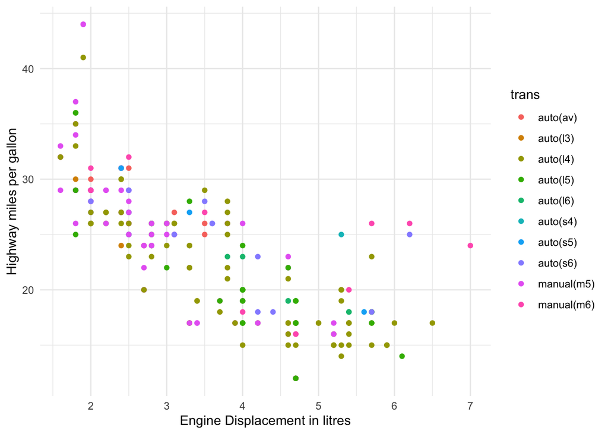

```r
# title of axis can be accessed by `labs` (labels)
ggplot(mpg) +
  geom_point(aes(x = displ,
                 y = hwy,
                 colour = trans)) +
  labs(x = "Engine Displacement in litres",
       y = "Highway miles per gallon") +
  theme_minimal()
```

#### Question 9

Create a scatter plot showing the relationship between engine displacement and city miles, including a line of best fit.

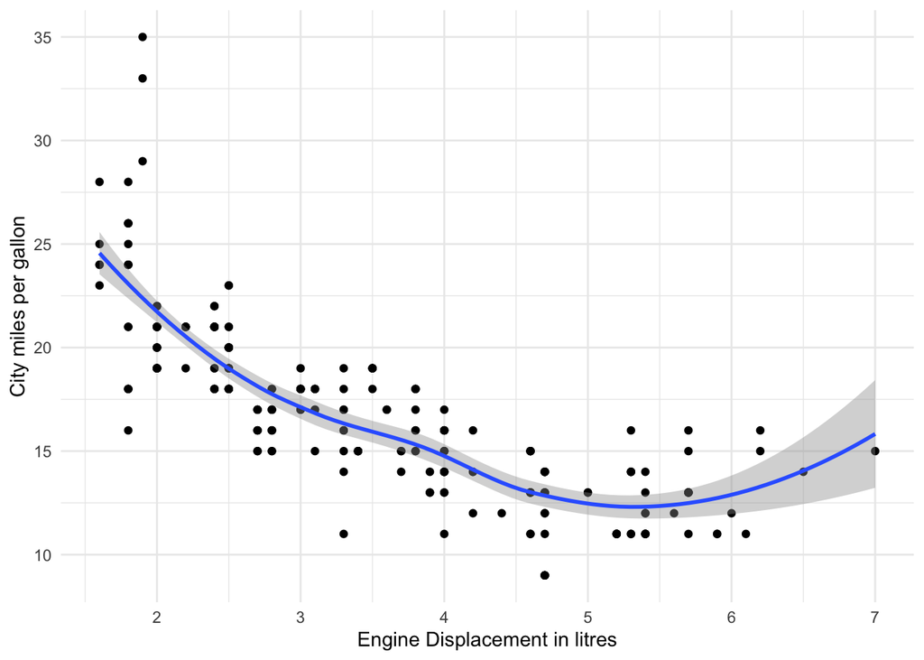

```r
# title of axis can be accessed by `labs` (labels)
# aes() must be inside ggplot now, x and y are required by geom_smooth()

ggplot(mpg, aes(x = displ,
                 y = cty)) +
  geom_point() +
  geom_smooth() +
  labs(x = "Engine Displacement in litres",
       y = "City miles per gallon") +
  theme_minimal()
```

#### Question 10

Recreate the previous plot, but adding colour = class to the aesthetic mappings. Use method = “lm” and set se = FALSE in geom_smooth(). What difference does this make?

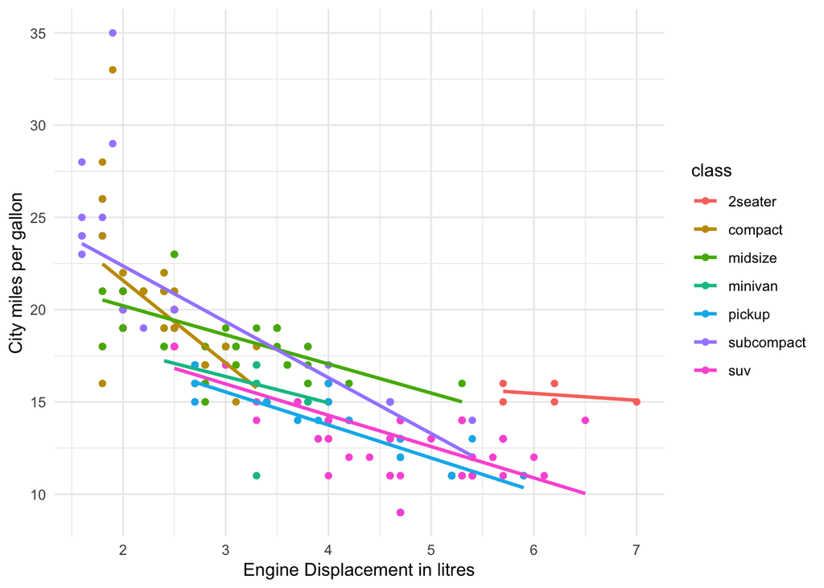

```r
# title of axis can be accessed by `labs` (labels)
# aes() must be inside ggplot now, x and y are required by geom_smooth()

ggplot(mpg, aes(x = displ,
                y = cty,
                colour = class)) +
  geom_point() +
  geom_smooth(method = "lm",
              se = FALSE) +
  labs(x = "Engine Displacement in litres",
       y = "City miles per gallon") +
  theme_minimal()
```

There are three modifications. First, adding colour to the aesthetic mappings creates clusters using the `class` variable. As a result, `geom_smooth()` fits separate lines for each of these colour clusters. Second, the `method = "lm"` argument stands for linear model and finds a linear relationship in the data, fitting a linear line, instead of a line full of curves. Third, the argument `se = FALSE` displays no confidence interval around the smooth.

For comparison, let’s try plotting without `se` set to `FALSE`.

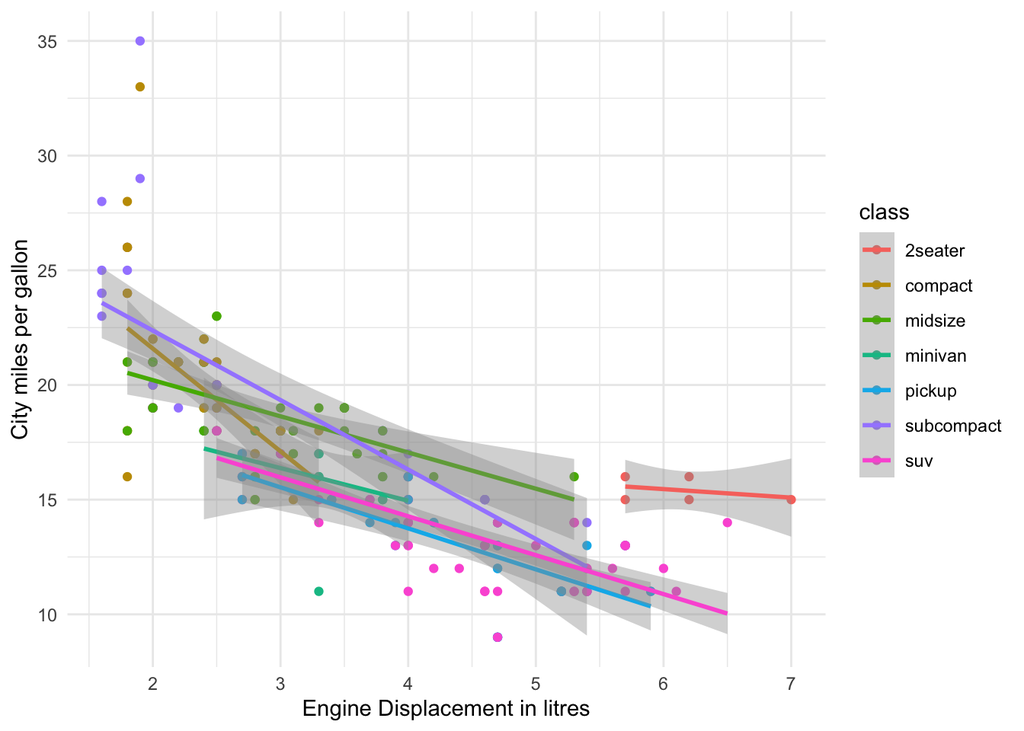

```r
ggplot(mpg, aes(x = displ,
                y = cty,
                colour = class)) +
  geom_point() +
  geom_smooth(method = "lm") +
  labs(x = "Engine Displacement in litres",
       y = "City miles per gallon") +
  theme_minimal()
```

The plot is less readable with the display of overlapping confidence intervals.

#### Continuous - Categorical

Boxplots are often used to explore the distribution of a continuous variable broken down by a categorical variable.

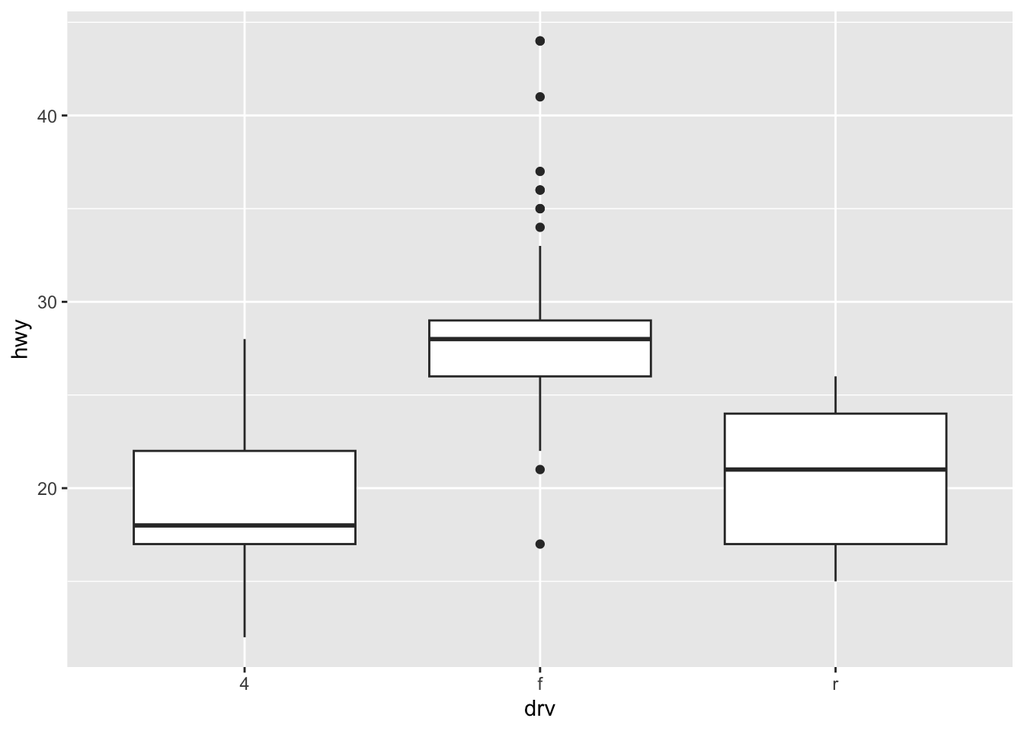

```r
ggplot(mpg) +
  geom_boxplot(aes(x = drv,
                   y = hwy))
```

These features of the boxplot are:

- Lower horizontal line
- Thicker horizontal middle line
- Upper horizontal line
- Vertical whiskers
- Points beyond the whiskers

#### Question 11

What do each of these features tell us?

- **Lower horizontal line**: represents the 1st quartile, or 25th percentile
- **Thicker horizontal middle line**: the median, represents the 2nd quartile, or 50th percentile
- **Upper horizontal line**: represents the 3rd quartile, or 75th percentile
- **Vertical whiskers**: the interquartile range (IRQ) is the range between Q1 and Q3. The whiskers are generated using the IQR and a measure of flexibility which is generally 1.5. The inferior whisker is defined as (Q1 - 1.5 * IQR), that is the 25th percentile minus one and a half times the interquartile range. The superior whisker as (Q3 + range * IQR), the 75th percentile plus one and a half times the interquartile range
- **Points beyond the whiskers**: represent outliers.

#### Question 12

Add + coord_flip() to the plot above. What does this do?

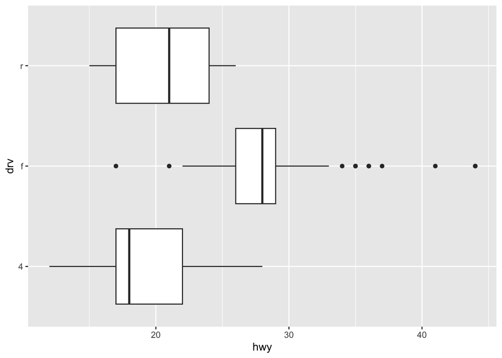

```r
ggplot(mpg) +
  geom_boxplot(aes(x = drv,
                   y = hwy)) +
  coord_flip()
```

`coord_flip()` flips the x and y axes, making the reading of bloxplot charts horizontal instead of vertical.

#### Question 13

What can you conclude about the highway miles per gallon of each type of drive train from the boxplot above?

Drive train “r” (rear-wheel) has a median of highway miles per gallon of a bit greater than 20. There are no outliers for this type of drive.

“f” stands for drive train type front-wheel. The group has the highest median of all three types of drive trains, a bit less than 30 highway miles per gallon. It also has many outliers, the dots beyond the whiskers, both beyond the maximum and minimum whiskers.

Drive train type “4” has no outliers. The group has the smallest median, making less than 20 highway miles per gallon.

#### Question 14

The variable `trans` contains 10 different transmissions types. These 10 categories can be assumed under 2 broader categories: manual and auto. Use `mutate()` and `fct_collapse()` to collapse the 10 categories of trans to just these 2 categories.

```r
# find the unique transmission types
unique(mpg$trans)
```

```
##  [1] auto(l5)   manual(m5) manual(m6) auto(av)   auto(s6)   auto(l4)
##  [7] auto(l3)   auto(l6)   auto(s5)   auto(s4)
## 10 Levels: auto(av) auto(l3) auto(l4) auto(l5) auto(l6) auto(s4) ... manual(m6)
```

```r
mpg <- mpg %>%
  mutate(trans = fct_collapse(trans,
                             "manual" = c("manual(m5)",
                                          "manual(m6)"),
                             "auto" = c("auto(av)",
                                        "auto(l3)",
                                        "auto(l4)",
                                        "auto(l5)",
                                        "auto(l6)",
                                        "auto(s4)",
                                        "auto(s5)",
                                        "auto(s6)")))

# check if mutation works
unique(mpg$trans)
```

```
## [1] auto   manual
## Levels: auto manual
```

#### Question 15

Use the previous example to create a boxplot mapping cty on the y-axis and drv on the x-axis, this time adding the argument colour = trans to aes(). What has changed?

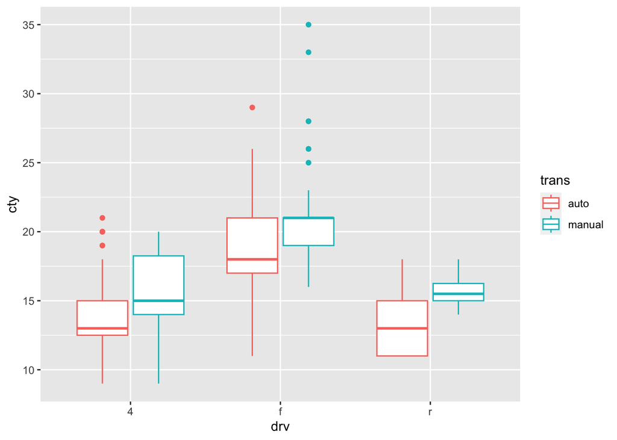

```r
ggplot(mpg) +
geom_boxplot(aes(x = drv,
                 y = cty,
                 colour = trans))
```